# Decomposition of states and time scales in the Nahant dataset

```r
library(tidyverse)
library(data.table)
library(cowplot)
library(ggraph)
library(igraph)
source("utils.R")
source("~/github_bitbucket/wkc.r-utils/df_2_mat.R")
knitr::opts_chunk$set(
  fig.path = "decomposition_nahant_figs/",
  fig.keep = "high",
  dev = c("pdf")
)
data.dir <- "../../data/"
script.dir <- "../../scripts/r/"
nahant.bac <- fread(paste0(data.dir, "BactNorm.txt"), header = TRUE)
nahant.bac <- melt(nahant.bac, id.vars = c("OTU", "ConsensusLineage"),
                   variable.name = "day")
nahant.bac <- nahant.bac[, day := as.numeric(as.character(day))]
nahant.bac <- nahant.bac[, value := as.numeric(value)]
# merge OTU counts by consensus lineage
nahant.bac <- nahant.bac[, .(freq = sum(value)), by = .(ConsensusLineage, day)]
# parse lineage
# nothing is mapped to species resolution
nahant.bac <- nahant.bac[, ConsensusLineage := gsub(";", "", ConsensusLineage)]
nahant.bac <- nahant.bac[, c("foo", "kingdom", "phylum", "class", "order", "family",
                             "genus") := tstrsplit(ConsensusLineage,
                                                   "[[:alpha:]]__")]
nahant.bac <- nahant.bac[, foo := NULL]
```

Here we aggregate all reads that map to the same phylum, which results in a manageable number of variables. But one could just as well aggregate at any other taxonomic level or not at all.

```r
phyla <- nahant.bac[kingdom != "" & phylum != "", .(freq = sum(freq)),
           by = .(day, phylum)]
```

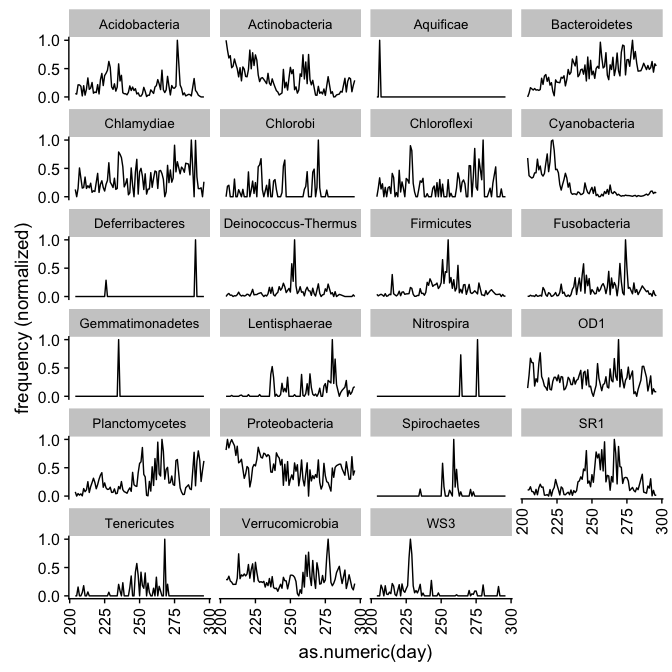

```r
phyla %>%
  group_by(phylum) %>%
  mutate(freq = scales::rescale(freq)) %>%
  ggplot(aes(x = as.numeric(day), y = freq)) +
  theme(strip.text = element_text(size = 10),
        axis.text.x = element_text(angle = 90, vjust = 0.5, hjust = 1)
        ) +
  scale_y_continuous(breaks = c(0, 0.5, 1)) +
  geom_line(aes(group = phylum)) +
  facet_wrap(~ phylum, ncol = 4) +
  labs(y = "frequency (normalized)")
```

We can look at the spectral density of the phyla time series. Phyla with peaks in the low frequencies exhibit slow fluctuations. It seems there really are slow and broad-spectrum taxa at this level.

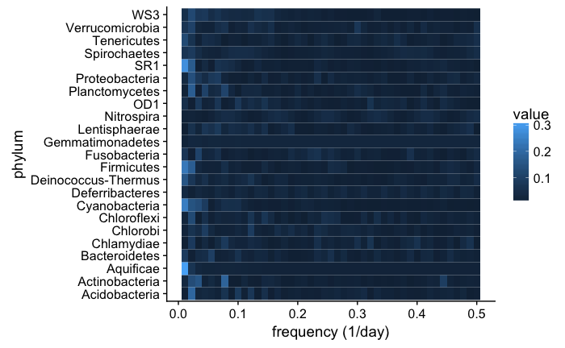

```r
phyla.spec <- phyla %>%
  dcast(day ~ phylum, value.var = "freq") %>%
  select(-day) %>%
  stats::spectrum(plot = FALSE)
phyla.spec <- data.table(cbind(phyla.spec$freq, phyla.spec$spec)) %>%
  setnames(c("freq", phyla.spec$snames)) %>%
  melt(id.vars = "freq", variable.name = "phylum")
phyla.spec %>%
  group_by(phylum) %>%
  mutate(value = value / sum(value)) %>%
  ggplot(aes(x = freq, y = phylum)) +
  labs(x = "frequency (1/day)") +
  geom_tile(aes(fill = value))
```

# R there statez?

Are there qualitative coarse-grainable compositional states in the Nahant data?

```r
phyla[, day := as.character(day)]
days <- unique(phyla[, day])
day.div <- data.table(expand.grid(day.i = days, day.j = days))
day.div[, ":=" (day.i = as.character(day.i),
                           day.j = as.character(day.j))]
setkey(phyla, day)
day.div[, jsd := {
  if (day.i == day.j) {
    0
  } else {
    sd <- phyla[c(day.i, day.j)]
    sd <- dcast(sd, phylum ~ day, value.var = "freq")
    m <- as.matrix(sd[, 2:3])
    d <- genJSD(m)
    d
  }
}, by = .(day.i, day.j)]
day.div[, distance := sqrt(jsd)]
```

Layout the samples by Jensen-Shannon distance using `mds` algorithm. Color by day so as to see temporal progression. Hierarchically cluster by JS distance.

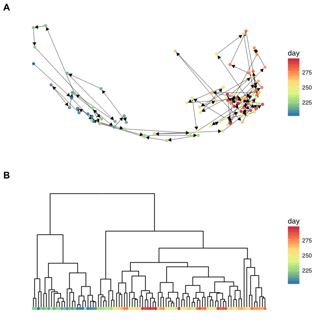

```r
edges <- cbind(days[-length(days)], days[-1])
graph <- graph_from_data_frame(edges, directed = FALSE,
                               vertices = data.table(id = days,
                                                     day = as.numeric(days)))
dm <- MakeDistMatrix(day.div, "day.i", "day.j")
fit <- CoordCMDS(dm)
xform <- fit$points
# order
setkey(xform, sample)
xform <- xform[V(graph)$name]
layout <- create_layout(graph, "manual", node.positions = xform)
p1 <- ggraph(layout) +
  geom_edge_link(arrow = arrow(type = "closed",
                               length = unit(5, "points")),
                 edge_width = 0.2,
                 end_cap = square(length = 5, unit = "points")
                 ) +
  geom_node_point(aes(color = day)) +
  theme_graph(base_family = "Helvetica") +
  scale_color_distiller(palette = "Spectral")
# clustering
hc <- hclust(dist(dm))
dendro <- as.dendrogram(hc)
dendro <- dendrapply(dendro, function(d) {
  if (is.leaf(d)) {
    attr(d, "nodePar") <- list(day = as.numeric(attr(d, "label")))
  }
  d
})
p2 <- ggraph(dendro, "dendrogram") +
  geom_edge_elbow() +
  # geom_node_text(aes(filter = leaf, color = day, label = day), angle = 90, size = 2) +
  geom_node_point(aes(filter = leaf, color = day)) +
  scale_color_distiller(palette = "Spectral") +
  theme_graph(base_family = "Helvetica") #+
  # theme(aspect.ratio = 1)
plot_grid(p1, p2, nrow = 2, align = "hv", labels = c("A", "B"))
```

These data show a clear transition between stable states around day 240. These two states form the two major branches at the lowest level of the hierarchical clustering.

The eigenvalues of the MDS transform show that information is well preserved:

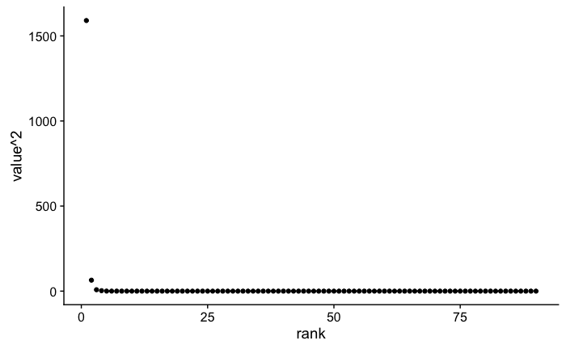

```r
ggplot(fit$eigrank, aes(x = rank, y = value ^ 2)) +
  geom_point()
```

## Statistics of dynamics

Distribution of daily compositional step sizes. The Maxwell-Boltzmann/lognormal shape to the density at $\Delta(t) = 1$ suggests that under this time resolution the change in composition behaves like some kind of random walk, with a characteristic step size and rare changes of larger magnitude.

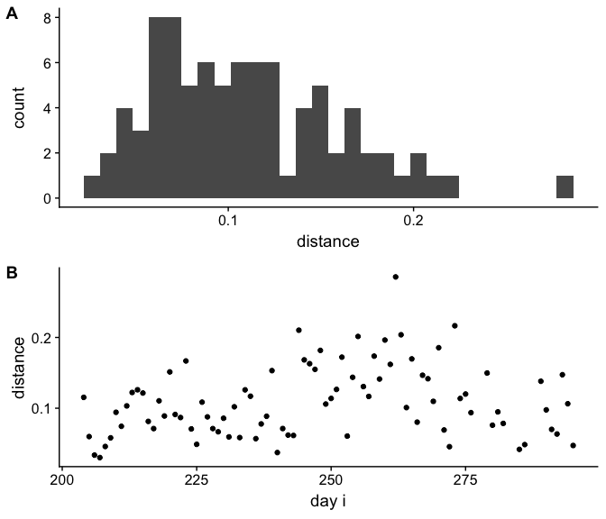

```r
day.div <- day.div[, day.delta := as.numeric(day.j) - as.numeric(day.i)]
p1 <- ggplot(day.div[day.delta == 1,], aes(x = distance)) +
  stat_bin(bins = 30)
p2 <- ggplot(day.div[day.delta == 1], aes(x = as.numeric(day.i), y = distance)) +
  geom_point() +
  # stat_smooth() +
  labs(x = "day i")
plot_grid(p1, p2, nrow = 2, labels = "AUTO", align = "hv")
```

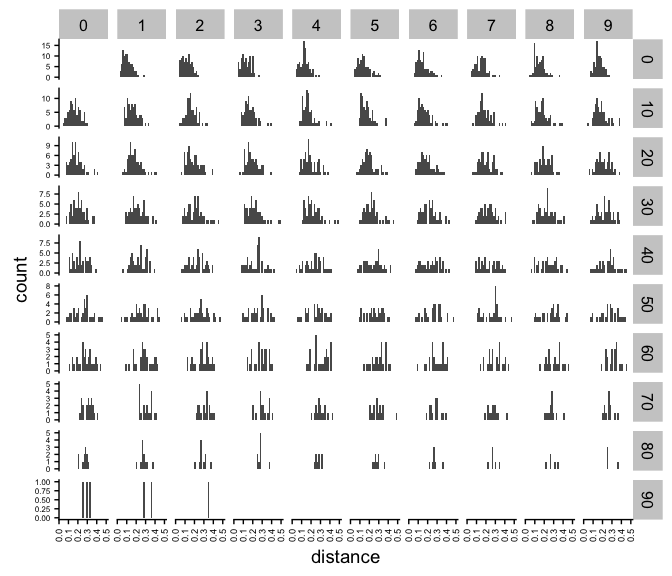

```r
day.div[day.delta > 0] %>%
  mutate(group = as.factor(floor(day.delta / 10) * 10),
         ddelta = as.factor(day.delta %% 10)) %>%
  ggplot(aes(x = distance)) +
  stat_bin(bins = 30, position = "identity") +
  scale_color_brewer(palette = "Spectral") +
  theme(axis.text.x = element_text(angle = 90, vjust = 0.5, hjust = 1,
                                   size = 7
                                   ),
        axis.text.y = element_text(size = 6)
        ) +
  facet_grid(group ~ ddelta, scales = "free_y")
```

Compositional distance as function of interval. This is sort of an autocorrelation spectrum. There are no peaks in this ‘spectrum’ suggesting there are no characteristic time scales of periodic behavior. Since there is only one major state transition in these data, it could also be interpreted as the period of state transitions being longer than the observation time, when interpreted as periodic.

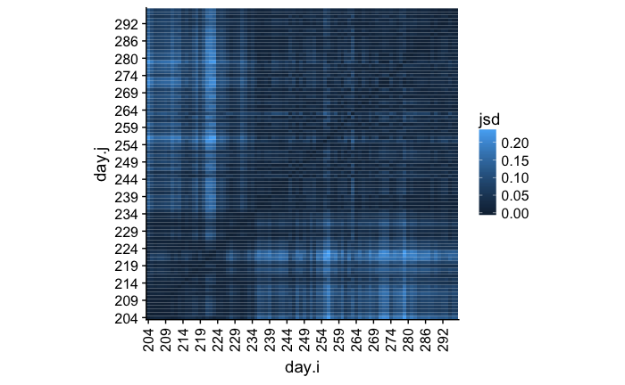

```r
br <- days[seq(1, length(days), by = 5)]
ggplot(day.div, aes(x = day.i, y = day.j)) +
  geom_tile(aes(fill = jsd)) +
  scale_x_discrete(breaks = br) +
  scale_y_discrete(breaks = br) +
  theme(aspect.ratio = 1,
        axis.text.x = element_text(angle = 90, vjust = 0.5, hjust = 1))
```

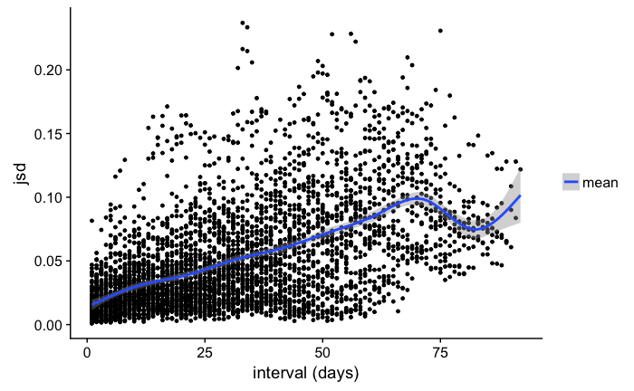

```r
ggplot(day.div[day.delta > 0], aes(x = day.delta, y = jsd)) +
  geom_point(size = 1) +
  stat_smooth(aes(linetype = "mean"))  +
  # geom_line(aes(y = mn.dist, linetype = "mean"), tl, color = "blue", size = 2) +
  labs(linetype = "", x = "interval (days)")
```

## Modularization

Try to find states as modules in the network of JSDs between timepoints.

### Greedy algorithm (Louvain)

Reference: [Blondel 2008](https://arxiv.org/abs/0803.0476).

```r
day.div[, similarity := 1 - jsd]
graf <- graph_from_data_frame(day.div[as.numeric(day.i) < as.numeric(day.j),
                                      .(day.i, day.j, weight = similarity)],
                              directed = FALSE,
                              vertices = unique(day.div[, day.i]))
system.time(clust <- cluster_louvain(graf))
```

```
   user  system elapsed
  0.022   0.000   0.026
```

```r
modularity(clust)
```

```
[1] 0.006688169
```

```r
membership(clust)
```

```
204 205 206 207 208 209 210 211 212 213 214 215 216 217 218 219 220 221 222 223 224 225 226 227 228 229
  1   1   1   1   1   1   1   1   1   1   1   1   1   1   1   1   1   1   1   1   1   1   1   1   2   1
230 231 232 233 234 235 236 237 238 239 240 241 242 243 244 245 246 247 248 249 250 251 252 253 254 255
  1   1   1   1   1   2   2   2   2   2   2   2   2   2   2   2   2   2   2   2   2   2   2   2   2   2
256 257 258 259 260 261 262 263 264 265 266 267 268 269 270 271 272 273 274 275 276 277 279 280 281 282
  2   2   2   2   2   2   2   2   2   2   2   2   2   2   2   2   2   2   2   2   2   2   2   2   2   2
283 285 286 287 289 290 291 292 293 294 295 296
  2   2   2   2   2   2   2   2   2   2   2   2
```

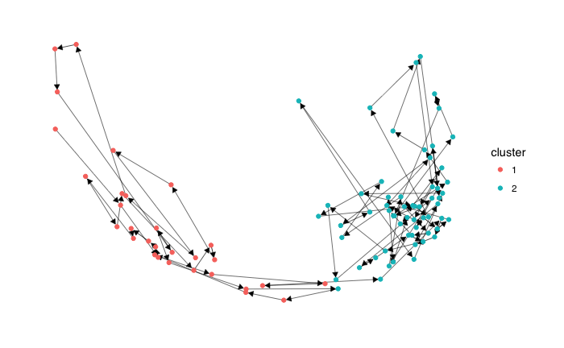

```r
clust.dt <- data.table(cluster = as.character(membership(clust)),
                       day = names(membership(clust)))
setkey(clust.dt, day)
V(graph)$cluster <- clust.dt[V(graph)$name, cluster]
layout <- create_layout(graph, "manual", node.positions = xform)
ggraph(layout) +
  geom_edge_link(arrow = arrow(type = "closed",
                               length = unit(5, "points")),
                 edge_width = 0.2,
                 end_cap = square(length = 5, unit = "points")
                 ) +
  geom_node_point(aes(color = cluster)) +
  theme_graph(base_family = "Helvetica")
```

### Time-lagged state correlation

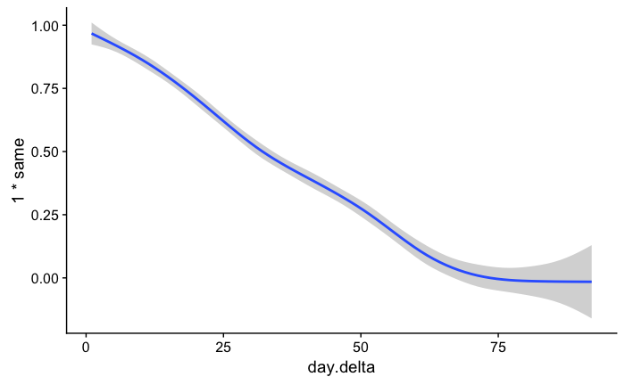

```r
day.div <- merge(day.div, clust.dt, by.x = "day.i", by.y = "day")
day.div <- merge(day.div, clust.dt, by.x = "day.j", by.y = "day",
                 suffixes = c(".i", ".j"))
day.div[, same := cluster.i == cluster.j]
ggplot(day.div[day.delta > 0], aes(x = day.delta, y = 1* same)) +
  geom_smooth()
```